# Assignment 3 for Statistical Computing and Empirical Methods: Visualisation with R

Henry Reeve

# Introduction

This document describes your third assignment for Statistical Computing and Empirical Methods (Unit EMATM0061) on the MSc in Data Science. Before starting the assignment it is recommended that you first watch video lecture 3 entitled “Visualisation with R”. The goal of this assignment is for you to gain an understanding of the basics of visualisation with R using the ggplot2 library.

Begin by creating an Rmarkdown document with html output. You are not expected to hand in this piece of work, but it is a good idea to get used to using Rmarkdown.

You will need to install the Tidyverse set of packages if you have not already done so:

```
install.packages("tidyverse")
```

Next load the Tidyverse library which is a superset of the ggplot2 library which we shall use for this assignment.

```r
library(tidyverse)
```

For the purpose of this assignment we shall use the Hawks data set from the Stat2Data package. This is a brilliant data set containing information about 908 Hawks collected by students and faculty at Cornell College in Mount Vernon, Iowa. First install the “Stat2Data” library:

```
install.packages("Stat2Data")
```

We can then load the data set as follows.

```r
library(Stat2Data)
data("Hawks")
```

This will load a data frame called “Hawks” into your environment. We will use a slightly smaller dataframe which we construct as follows:

```r
hawksSmall<-drop_na(select(Hawks,Age,Day,Month,Year,CaptureTime,Species,Wing,Weight,Tail))
```

The functions used within this code snippet will be discussed in the next lecture.

# 1 Types of variables

Check how many rows and columns **hawksSmall** using the **dim()** function. Use the **head()** function to display the top 5 rows of the **hawksSmall** data frame. Your result should look something like this:

```
##   Age Day Month Year CaptureTime Species Wing Weight Tail
## 1   I  19     9 1992       13:30      RT  385    920  219
## 2   I  22     9 1992       10:30      RT  376    930  221
## 3   I  23     9 1992       12:45      RT  381    990  235
## 4   I  23     9 1992       10:50      CH  265    470  220
## 5   I  27     9 1992       11:15      SS  205    170  157
```

For each of the following variables say whether they continuous, discrete or categorical:

1. Month: Discrete
2. Species: Categorical
3. Age: Categorical (or ordinal)
4. Wing: Continuous (or discrete)
5. Weight: Continuous (or discrete)

The information available at https://rdrr.io/cran/Stat2Data/man/Hawks.html may help.

# 2 What’s wrong with this plot?

Write down some problems with the plot displayed below.

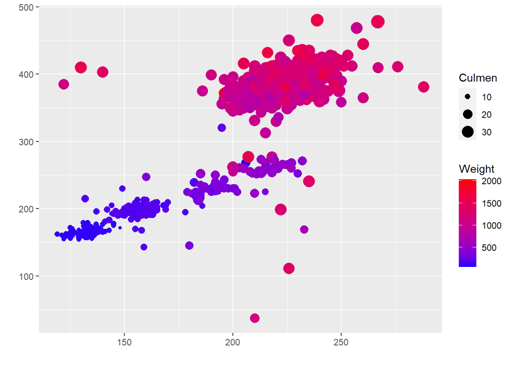

Problems:

1. No labels
2. Trys to include far too much information - too many aesthetics.

# 3 Generate a histogram

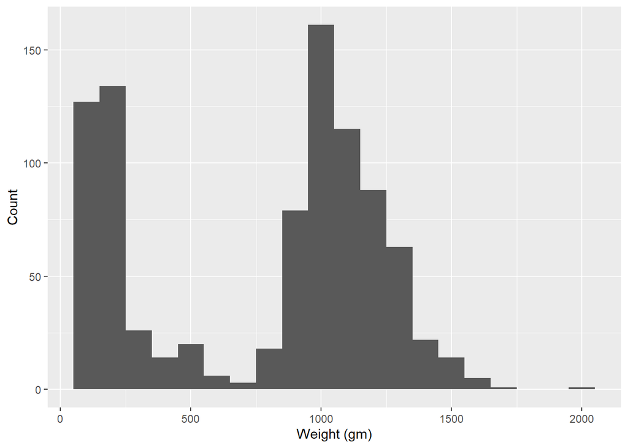

```r
ggplot(data=hawksSmall,aes(x=Weight))+geom_histogram(binwidth=100)+xlab("Weight (gm)")+ylab("Count")
```

Describe the aesthetic used within this plot:

Weight is mapped to horizontal position.

Which term best describes the shape of the data distribution of Hawk weights: “Unimodal”, “Bimodal” or “Trimodal”?

Bimodal

# 4 Generate a density plot

Use a combination of the functions **ggplot()** and **geom_density()** to create a density plot of the tail lengths of the Hawks within the **hawksSmall** data frame. Your result should something like this:

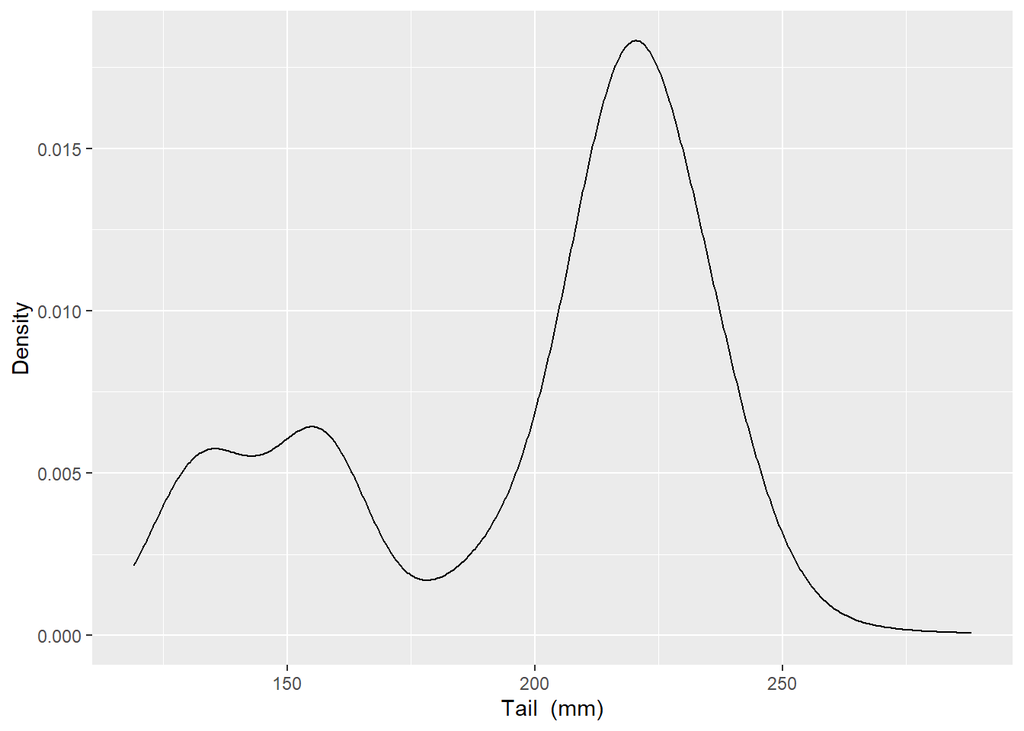

```r
ggplot(data=hawksSmall,aes(x=Tail))+geom_density()+xlab("Tail  (mm)")+ylab("Density")
```

Recreate your plot with the argument `adjust = 0.5` and `adjust = 1`. Describe the role played by the adjust argument within the **geom_density()** function.

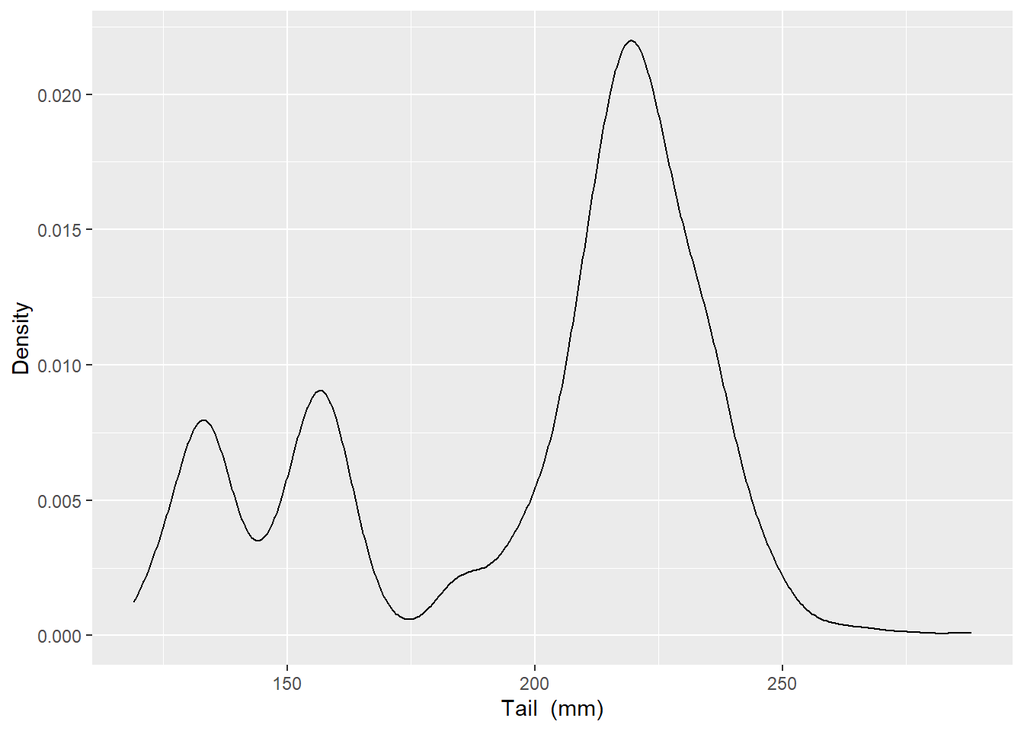

```r
ggplot(data=hawksSmall,aes(x=Tail))+geom_density(adjust=0.5)+xlab("Tail  (mm)")+ylab("Density")
```

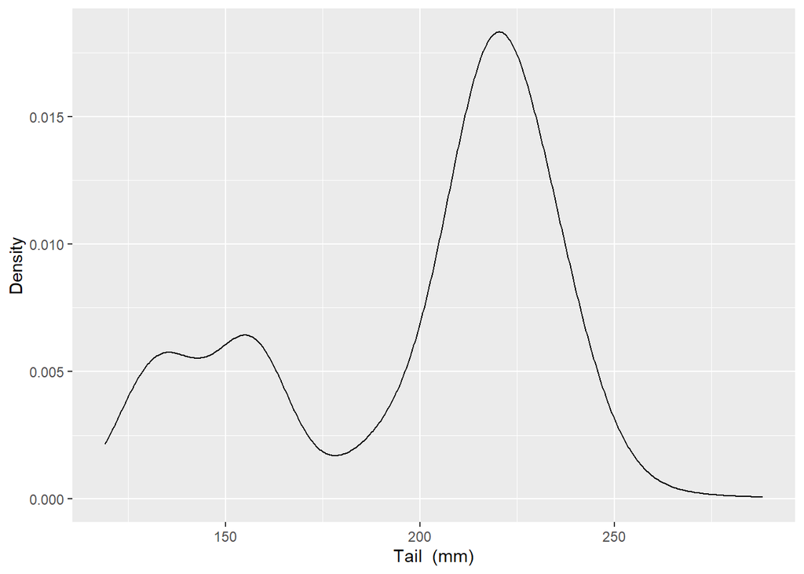

```r
ggplot(data=hawksSmall,aes(x=Tail))+geom_density(adjust=1)+xlab("Tail  (mm)")+ylab("Density")
```

How many modes does the data distribution of Hawk tail lengths have?

The point here is that number of modes is not a clearly defined concept. In this case there are two large modes which stands out with adjust=1 but the first mode appears to contain two smaller modes when plotted at a finer level of granularity with adjust=0.5. The number of modes is generally not a completely unambiguous concept.

Create the following plots for yourself:

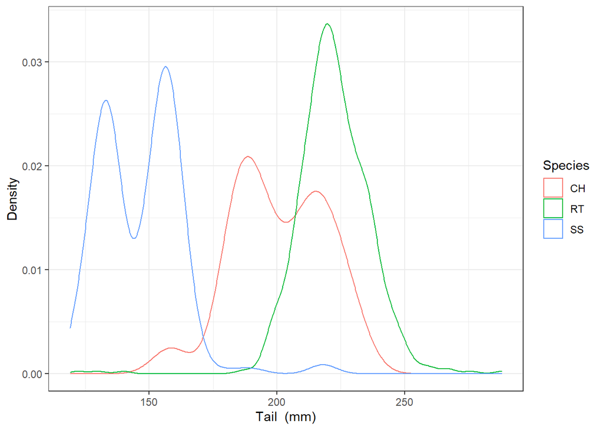

```r
ggplot(data=hawksSmall,aes(x=Tail,color=Species))+geom_density()+xlab("Tail  (mm)")+ylab("Density")+theme_bw()
```

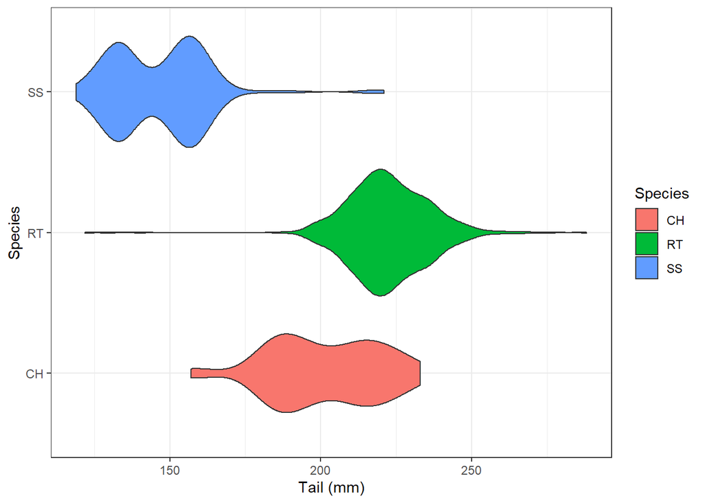

```r
ggplot(data=hawksSmall,aes(x=Tail,y=Species,fill=Species))+
  geom_violin()+theme_bw()+xlab("Tail (mm)")
```

# 5 Scatter plots

How many aesthetics are present within the following plot? What are the glyphs within this plot?

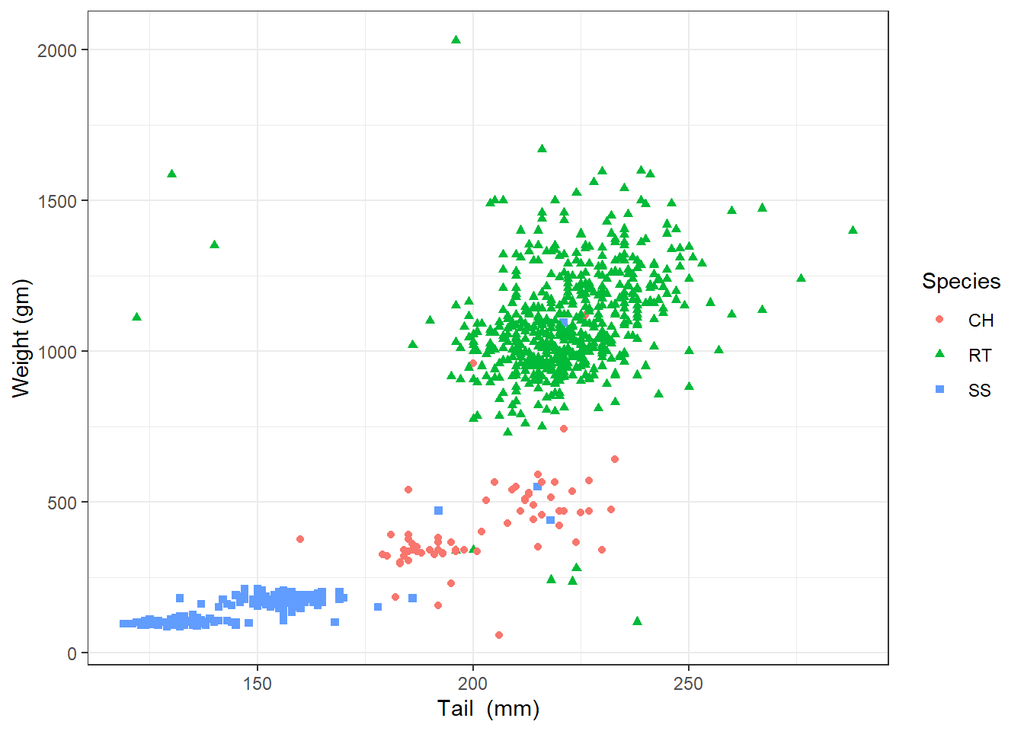

The aesthetis within the plot are as follows:

1. Tail length maps to horizontal position.
2. Weight maps to vertical position.
3. Species maps to colour.
4. Species maps to shape of glyph.

Generate a plot similar to the above plot using the **ggplot()** and **geom_point()** functions.

```r
ggplot(data=hawksSmall,aes(x=Tail,y=Weight,color=Species,shape=Species))+geom_point()+xlab("Tail  (mm)")+ylab("Weight (gm)")+theme_bw()
```

# 6 Trend lines and facet wraps

Generate the following plot using the **ggplot()**, **geom_point()**, **geom_smooth()** and **facet_wrap()** functions.

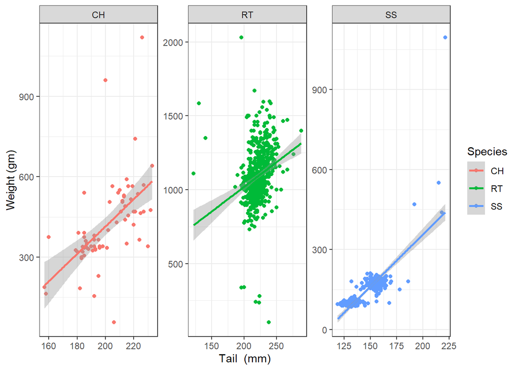

```r
g<-ggplot(data=hawksSmall,aes(x=Tail,y=Weight,color=Species))+
  geom_point()+xlab("Tail  (mm)")+ylab("Weight (gm)")+geom_smooth(method="lm")+
  theme_bw()+facet_wrap(~Species,scales = "free")
g
```

What are the visual cues being used within this plot?

Based on the above plot, what can we say about the relationship between the weight of the hawks and their tail lengths?

Based on this sample, longer tail lengths appear to be predictive of larger weights within each species.

As an additional challenge, if you have time, you could try adding an annotation to your plot which highlights the weight of the heaviest hawk in the data set.

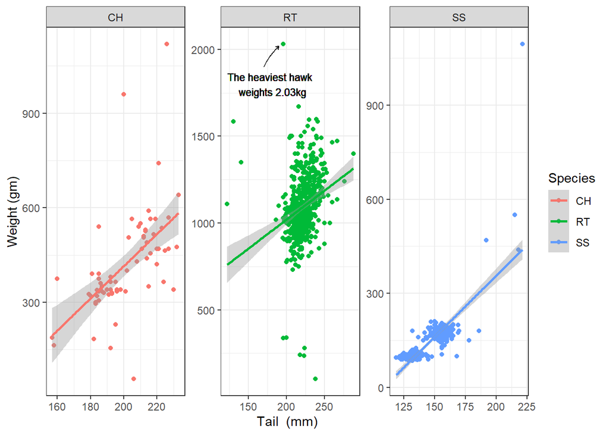

```r
max_weight<-max(hawksSmall$Weight)

label=paste("The heaviest hawk \n weights ", as.character(max_weight/1000),"kg",sep="")

g+geom_curve(x=170,xend=190,y=1900,yend=2020,arrow=arrow(length=unit(0.1,"cm")),
             curvature = -0.1,color="black")+
  geom_text(x=180,y=1800,label=label,size=3,color="black")
```

If you want to learn more about ggplot2 take a look at the ggplot2 gallery https://exts.ggplot2.tidyverse.org/gallery.